# BCB420 Assignment 1: Data set selection and initial processing

Veronica Chang

February 14th, 2023

# Task 1: Install packages and select an expression data set

## Packages

- BiocManager (Morgan 2022)
- [GEOmetadb](https://bioconductor.org/packages/release/bioc/html/GEOmetadb.html) (Zhu 2008)
- [limma](https://bioconductor.org/packages/release/bioc/html/limma.html) (Smyth 2015)
- [edgeR](https://bioconductor.org/packages/release/bioc/html/edgeR.html) (Robinson 2010)
- [biomaRt](https://bioconductor.org/packages/release/bioc/html/biomaRt.html) (Durinck 2009)
- [GEOquery](https://bioconductor.org/packages/release/bioc/html/GEOquery.html) (Davis 2007)
- [Biobase](https://bioconductor.org/packages/release/bioc/html/Biobase.html) (Huber 2015)
- RColorBrewer (Neuwirth 2022)

```r
if (!requireNamespace("BiocManager", quietly = TRUE))
    install.packages("BiocManager")
if (!requireNamespace("GEOmetadb", quietly = TRUE))
    BiocManager::install("GEOmetadb")

library("BiocManager")
library("GEOmetadb")
library("limma")
library("edgeR")
library("dplyr")
library("Biobase")
library("biomaRt")
library("GEOquery")
library("RColorBrewer")
library("ggplot2")
library("knitr")
library("RSQLite")
library("kableExtra")
```

## Selected the dataset GSE111972

Description below (Poel 2019)

```r
gseAccession <- "GSE111972"
gse <- GEOquery::getGEO(gseAccession, GSEMatrix = FALSE)
gpl <- names(GEOquery::GPLList(gse))[1]
gplInfo <- GEOquery::Meta(GEOquery::getGEO(gpl))
```

## Introduction

### Background

Multiple sclerosis (MS) is a chronic neuroinflammatory autoimmune disease. MS is characterized by demyelination and subsequent formation of lesions through out the central nervous system (CNS). Grey matter (GM) and white matter (WM) lesions in the brain show pathological differences. Microglia are CNS-resident and can function as antigen-presenting cells and phagocytes. Their role in MS is complex and controversial (Luo 2017).

### General Experimental Design

In total 31 human microglia samples were analyzed from 10 MS donors (MS), including 5 grey matter and 10 white matter samples, and from 11 non-neurological control donors (CON), including 5 grey matter and 11 white matter samples. From each sample total RNA was extracted (Poel 2019).

### Study objectives

The authors isolated human microglia according to the previously described general experimental design. They suggest that pathological changes in MS tissue may be associated with changes in microglia, leading to lesion initiation. The authors wanted to analyze the transcriptional profile of microglia in the collected samples by RNA-sequencing (Luo 2017). Ultimately, they wanted to discover MS-related changes in microglia between the GM and WM brain regions.

# Task 2: Clean the data and map to HUGO symbols

## Fetch the data set

```r
gseDir <- "/home/rstudio/projects/A1"
if (!file.exists("~/projects/A1/GSE111972/GSE111972_norm_data.txt")) {
    sFiles = GEOquery::getGEOSuppFiles(gseAccession)
    fName = rownames(sFiles)
    GEOquery::gunzip(fNames[1])
}
```

There is only one supplemental file for this study.

```r
file <- list.files(path = "~/projects/A1/GSE111972/", pattern = "\\.txt")
expData <- read.table(paste0("~/projects/A1/GSE111972/", file), sep = "\t", header = TRUE,
    check.names = FALSE)
colnames(expData)[2:32] <- sub("Sample_", "", colnames(expData))[2:32]
dim(expData)
```

```
## [1] 21283    32
```

From this we see there are 21283 rows and 32 columns (the first being the Gene ID) in this data set. The rows correspond to genes and the columns correspond to the different samples. The samples can be divided into `patient_group`, MS and CON, and `tissue`, GM, WM.

## Define the groups

```r
# going to remove the 'Sample_' portion from the column names as they do not
# hold any information
samples <- data.frame(lapply(colnames(expData)[2:32], FUN = function(x) {
    unlist(strsplit(x, split = "\\_"))[c(1, 2, 3)]
}))
colnames(samples) <- sub("Sample_", "", colnames(expData))[2:32]
rownames(samples) <- c("patient_group", "tissue", "replicate")
samples <- data.frame(t(samples))

# made another group that combined patient_group and tissue for easier
# comparison
samples$group <- paste(samples$patient_group, samples$tissue)

samples
```

|  | patient_group | tissue | replicate | group |
| --- | --- | --- | --- | --- |
| CON_GM_1 | CON | GM | 1 | CON GM |
| CON_WM_2 | CON | WM | 2 | CON WM |
| CON_GM_2 | CON | GM | 2 | CON GM |
| CON_WM_5 | CON | WM | 5 | CON WM |
| CON_GM_3 | CON | GM | 3 | CON GM |
| CON_WM_7 | CON | WM | 7 | CON WM |
| CON_GM_4 | CON | GM | 4 | CON GM |
| CON_WM_9 | CON | WM | 9 | CON WM |
| CON_GM_5 | CON | GM | 5 | CON GM |
| CON_WM_11 | CON | WM | 11 | CON WM |

[output cut: 21 more lines]

## Check for gene duplicates

```r
length(unique(expData$ID))
```

```
## [1] 21283
```

```r
!(length(unique(expData$ID)) == dim(expData)[1])
```

```
## [1] FALSE
```

There are no gene duplicates.

## Remove lowly expressed genes

```r
cpms = cpm(expData[, 2:32])
rownames(cpms) <- expData[, 1]

# get rid of low counts
keep = rowSums(cpms > 1) >= 10
expDataFiltered = expData[keep, ]
```

## Identifier mapping

### Build a Biomart Query

```r
# get available marts
listMarts()
```

| biomart | version |
| --- | --- |
| ENSEMBL_MART_ENSEMBL | Ensembl Genes 109 |
| ENSEMBL_MART_MOUSE | Mouse strains 109 |
| ENSEMBL_MART_SNP | Ensembl Variation 109 |
| ENSEMBL_MART_FUNCGEN | Ensembl Regulation 109 |

```r
ensembl <- useMart("ensembl")
datasets <- listDatasets(ensembl)
knitr::kable(head(datasets), format = "html")
```

| dataset | description | version |
| --- | --- | --- |
| abrachyrhynchus_gene_ensembl | Pink-footed goose genes (ASM259213v1) | ASM259213v1 |
| acalliptera_gene_ensembl | Eastern happy genes (fAstCal1.2) | fAstCal1.2 |
| acarolinensis_gene_ensembl | Green anole genes (AnoCar2.0v2) | AnoCar2.0v2 |
| acchrysaetos_gene_ensembl | Golden eagle genes (bAquChr1.2) | bAquChr1.2 |
| acitrinellus_gene_ensembl | Midas cichlid genes (Midas_v5) | Midas_v5 |
| amelanoleuca_gene_ensembl | Giant panda genes (ASM200744v2) | ASM200744v2 |

```r
# get only human
knitr::kable(head(datasets[grep(datasets$dataset, pattern = "sapiens"), ]), format = "html")
```

|  | dataset | description | version |
| --- | --- | --- | --- |
| 79 | hsapiens_gene_ensembl | Human genes (GRCh38.p13) | GRCh38.p13 |

```r
ensembl <- useDataset("hsapiens_gene_ensembl", mart = ensembl)
dim(listFilters(ensembl))
```

```
## [1] 435   2
```

```r
knitr::kable(listFilters(ensembl)[1:10, 1:2], type = "html")
```

| name | description |
| --- | --- |
| chromosome_name | Chromosome/scaffold name |
| start | Start |
| end | End |
| band_start | Band Start |
| band_end | Band End |
| marker_start | Marker Start |
| marker_end | Marker End |
| encode_region | Encode region |
| strand | Strand |
| chromosomal_region | e.g. 1:100:10000:-1, 1:100000:200000:1 |

```r
biomart_human_filters <- listFilters(ensembl)
```

### Attributes

```r
kable(searchAttributes(mart = ensembl, "hgnc"), format = "html") %>%
    row_spec(2, background = "yellow")
```

|  | name | description | page |
| --- | --- | --- | --- |
| 62 | hgnc_id | HGNC ID | feature_page |
| 63 | hgnc_symbol | HGNC symbol | feature_page |
| 93 | hgnc_trans_name | Transcript name ID | feature_page |

```r
httr::set_config(httr::config(ssl_verifypeer = FALSE))
ensembl <- biomaRt::useMart("ensembl", dataset = "hsapiens_gene_ensembl")
```

### Check for genes without HGNC annotation

```r
conversion_stash <- "geneIDConversion.rds"
if (file.exists(conversion_stash)) {
    geneIDConversion <- readRDS(conversion_stash)
} else {
    geneIDConversion <- biomaRt::getBM(attributes = "hgnc_symbol", filters = "hgnc_symbol",
        values = expDataFiltered$ID, mart = ensembl)
    saveRDS(geneIDConversion, conversion_stash)
}

# find the genes that do not use HGNC annotation
not_hgnc <- expDataFiltered[-(which(rownames(keep) %in% geneIDConversion$hgnc_symbol)),
    ]
```

Seems like all genes are already annotated with HGNC symbols. The authors may have already filtered the genes.

# Task 3: Apply Normalization

## Check statistical summaries

```r
summaryStats <- data.frame(apply(expDataFiltered[, 2:32], 2, summary))
summaryStats
```

|  | CON_GM_1 | CON_WM_2 | CON_GM_2 | CON_WM_5 | CON_GM_3 | CON_WM_7 | CON_GM_4 | CON_WM_9 | CON_GM_5 | CON_WM_11 | CON_WM_1 | CON_WM_10 | CON_WM_3 | CON_WM_4 | CON_WM_6 | CON_WM_8 | MS_GM_1 | MS_WM_2 | MS_GM_3 | MS_WM_5 | MS_GM_4 | MS_WM_6 | MS_GM_5 | MS_WM_10 | MS_GM_6 | MS_WM_11 | MS_WM_1 | MS_WM_3 | MS_WM_7 | … |
| --- | --- | --- | --- | --- | --- | --- | --- | --- | --- | --- | --- | --- | --- | --- | --- | --- | --- | --- | --- | --- | --- | --- | --- | --- | --- | --- | --- | --- | --- | --- |
| Min. | 0.0000 | 0.0000 | 0.0000 | 0.0000 | 0.0000 | 0.0000 | 0.0000 | 0.000 | 0.0000 | 0.0000 | 0.0000 | 0.0000 | 0.0000 | 0.0000 | 0.000 | 0.0000 | 0.0000 | 0.0000 | 0.0000 | 0.0000 | 0.0000 | 0.0000 | 0.0000 | 0.0000 | 0.0000 | 0.000000e+00 | 0.0000 | 0.0000 | 0.0000 | … |
| 1st Qu. | 72.6547 | 73.3709 | 64.2504 | 72.2307 | 57.9226 | 88.1281 | 67.0014 | 91.921 | 79.2259 | 88.4073 | 95.9583 | 94.1236 | 87.1442 | 77.4249 | 113.884 | 97.8366 | 82.0326 | 87.1078 | 88.9043 | 70.6461 | 72.8732 | 82.4891 | 61.5527 | 49.7936 | 70.0603 | 6.859895e+01 | 61.8028 | 90.4208 | 97.6872 | … |
| Median | 317.3860 | 323.1810 | 301.3430 | 296.3950 | 304.4470 | 328.8220 | 299.3680 | 315.874 | 321.3540 | 305.6370 | 319.3370 | 320.5835 | 315.1380 | 300.9760 | 372.021 | 320.6870 | 316.9900 | 319.8490 | 342.4840 | 301.9280 | 337.3530 | 306.3880 | 303.1265 | 262.3270 | 319.8050 | 3.043880e+02 | 294.1220 | 317.4350 | 333.0780 | … |
| Mean | 994.5265 | 1697.8347 | 945.6508 | 1427.8850 | 977.9678 | 1132.2659 | 954.6128 | 1069.730 | 999.2330 | 1388.1831 | 1535.5615 | 1149.0724 | 1211.0048 | 1197.5743 | 1110.032 | 1135.8374 | 1059.1084 | 1560.4434 | 1077.9992 | 1159.5962 | 893.8065 | 1153.0250 | 992.1206 | 1424.9048 | 997.5126 | 1.470949e+03 | 1174.4200 | 1225.9139 | 1451.2060 | … |
| 3rd Qu. | 893.8440 | 920.6300 | 863.3080 | 906.6190 | 878.7280 | 896.4430 | 878.3243 | 895.812 | 907.9820 | 894.4928 | 911.2112 | 894.5770 | 871.4420 | 882.2070 | 933.217 | 911.7822 | 882.3562 | 899.6600 | 927.4340 | 885.6000 | 905.8890 | 881.6700 | 870.1700 | 938.7920 | 898.6260 | 8.831720e+02 | 877.3390 | 881.1220 | 921.8502 | … |
| Max. | 320573.0000 | 1828470.0000 | 156477.0000 | 530911.0000 | 251569.0000 | 506205.0000 | 268929.0000 | 456505.000 | 240954.0000 | 1168260.0000 | 1434970.0000 | 502433.0000 | 787239.0000 | 330650.0000 | 396782.000 | 556511.0000 | 455535.0000 | 1596000.0000 | 431951.0000 | 498889.0000 | 113266.0000 | 563619.0000 | 684270.0000 | 681093.0000 | 237596.0000 | 1.318410e+06 | 593987.0000 | 660183.0000 | 833882.0000 | … |

```r
# Calculate the summary statistics for each group

# CON (non-neurological control) WM (white matter)
summaryCONWM <- summary(rowMeans(expDataFiltered[, grep("CON_WM", colnames(expDataFiltered))]))
# MS (multiple sclerosis) WM (white matter)
summaryMSWM <- summary(rowMeans(expDataFiltered[, grep("MS_WM", colnames(expDataFiltered))]))
# CON (non-neurological control) GM (grey matter)
summaryCONGM <- summary(rowMeans(expDataFiltered[, grep("CON_GM", colnames(expDataFiltered))]))
# MS (multiple sclerosis) GM (grey matter)
summaryMSGM <- summary(rowMeans(expDataFiltered[, grep("MS_GM", colnames(expDataFiltered))]))

# Combine all
summaryStats2 <- rbind(summaryCONWM, summaryMSWM, summaryCONGM, summaryMSGM)
rownames(summaryStats2) <- c("CON WM", "MS WM", "CON GM", "MS GM")
knitr::kable(summaryStats2, format = "html", col.names = colnames(summaryStats2))
```

|  | Min. | 1st Qu. | Median | Mean | 3rd Qu. | Max. |
| --- | --- | --- | --- | --- | --- | --- |
| CON WM | 0.218976 | 104.66754 | 334.2293 | 1277.7256 | 915.8141 | 761692.4 |
| MS WM | 1.351720 | 99.22715 | 326.3115 | 1327.3035 | 934.7341 | 818231.8 |
| CON GM | 0.000000 | 83.91024 | 332.3691 | 974.3982 | 898.7470 | 211644.8 |
| MS GM | 0.000000 | 96.63128 | 343.5370 | 1004.1095 | 912.7484 | 265559.6 |

Means of the different groups are similar to each other for each tissue. This suggests that variations in gene counts can be attributed to biological variations rather than technical variations.

## Check distribution

### Define colour groups for plots

```r
# colour groups
tissueGroup <- as.factor(samples$tissue)
tissueGroup <- c("grey", "white")[tissueGroup]
patientGroup <- as.factor(samples$patient_group)
patientGroup <- c("forestgreen", "dodgerblue")[patientGroup]

colGroup <- as.factor(samples$group)
levels(colGroup) <- brewer.pal(nlevels(colGroup), "Spectral")
colGroup <- as.character(colGroup)
```

### Box plot

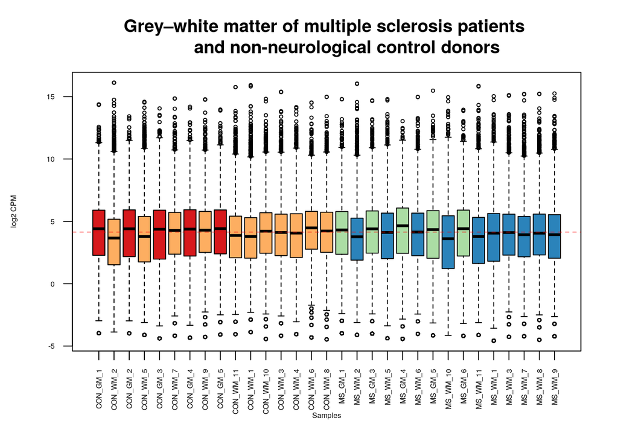

```r
# box plot
data2plot <- log2(cpm(expDataFiltered[, 2:32]))
boxplot(data2plot, xlab = "Samples", ylab = "log2 CPM", las = 2, cex = 0.5, cex.lab = 0.5,
    col = colGroup, cex.axis = 0.5, main = "Grey–white matter of multiple sclerosis patients
        and non-neurological control donors")

# draw the median on each box plot
abline(h = median(apply(data2plot, 2, median)), col = "red", lwd = 0.6, lty = "dashed")
```

**Figure 1. Box plot comparison differentiating between the different `patient_group` and `tissue`.**

The distribution and spread across all the samples are quite consistent.

### Density plot

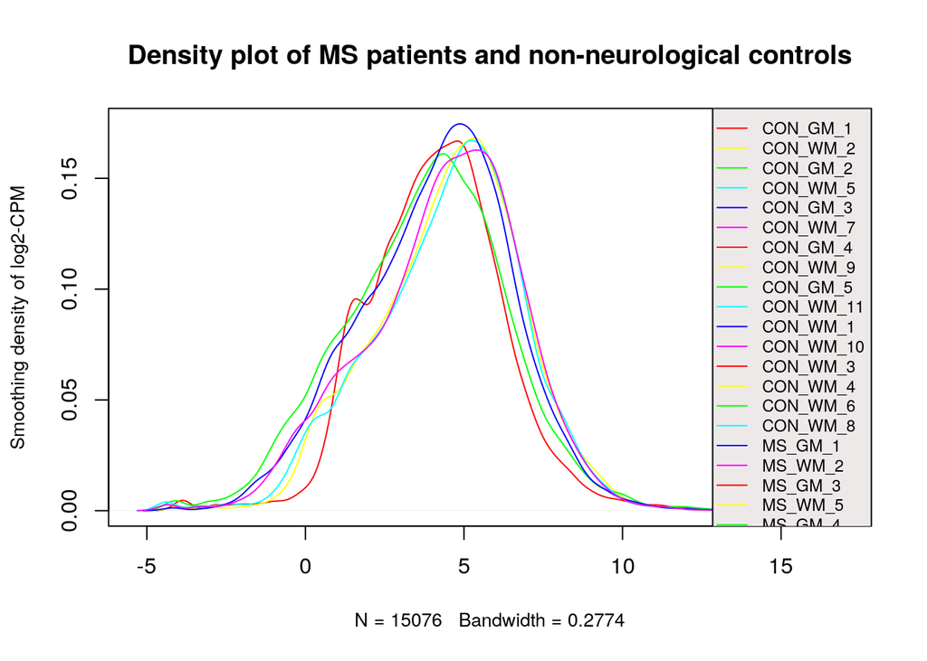

```r
# density plot
densityCounts <- apply(log2(edgeR::cpm(expDataFiltered[, 3:8])), 2, density)

# calculate limits
xlim <- 0
ylim <- 0
for (i in 1:length(densityCounts)) {
    xlim <- range(c(xlim, densityCounts[[i]]$x))
    ylim <- range(c(ylim, densityCounts[[i]]$y))
}

cols <- rainbow(length(densityCounts))
ltys <- rep(1, length(densityCounts))

# plot the first
plot(densityCounts[[1]], xlim = xlim, ylim = ylim, type = "n", ylab = "Smoothing density of log2-CPM",
    main = "", cex.lab = 0.85)

# plot the lines
for (i in 1:length(densityCounts)) lines(densityCounts[[i]], col = cols[i], lty = ltys[i])

# add legend
legend("topright", colnames(data2plot), col = cols, lty = ltys, cex = 0.75, border = "blue",
    text.col = "black", merge = TRUE, bg = "snow2")

title(main = "Density plot of MS patients and non-neurological controls")
```

## Apply TMM normalization

```r
filteredData <- as.matrix(expDataFiltered[, 2:32])
rownames(filteredData) <- expDataFiltered$ID
# create DGEList object
d <- edgeR::DGEList(counts = filteredData, group = samples$patient_group)
```

## Calculate the normalization factor

```r
d <- calcNormFactors(d)
expDataNorm <- cpm(d)
```

## Check distribution after normalization

### Boxplot

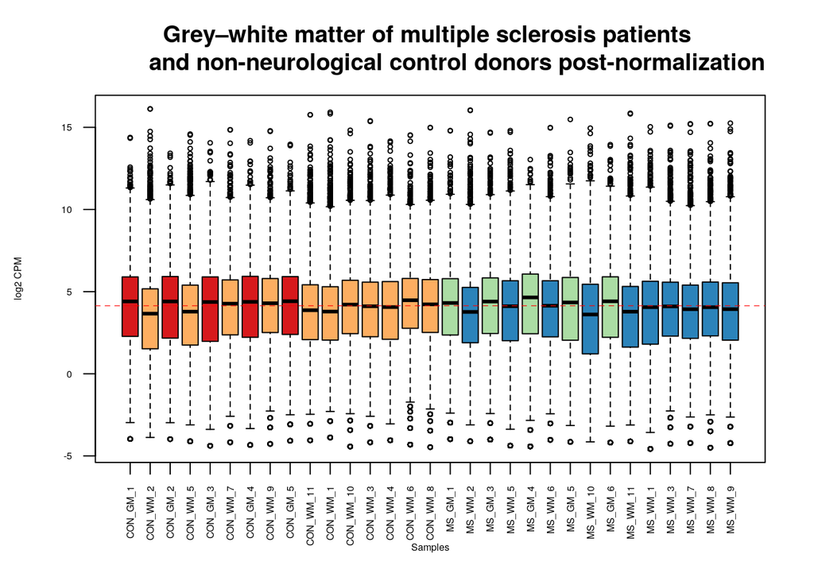

```r
data3plot <- log2(cpm(expDataNorm))
boxplot(data3plot, xlab = "Samples", ylab = "log2 CPM",
        las = 2, cex = 0.5, cex.lab = 0.5, col = colGroup,
        cex.axis = 0.5, main = "Grey–white matter of multiple sclerosis patients
        and non-neurological control donors post-normalization")

# draw the median on each box plot
abline(h = median(apply(data2plot, 2, median)),
       col = "red", lwd = 0.6, lty = "dashed")
```

**Figure 3. Box plot comparison differentiating between the different `patient_group` and `tissue` after TMM normalization.**

### Density plot

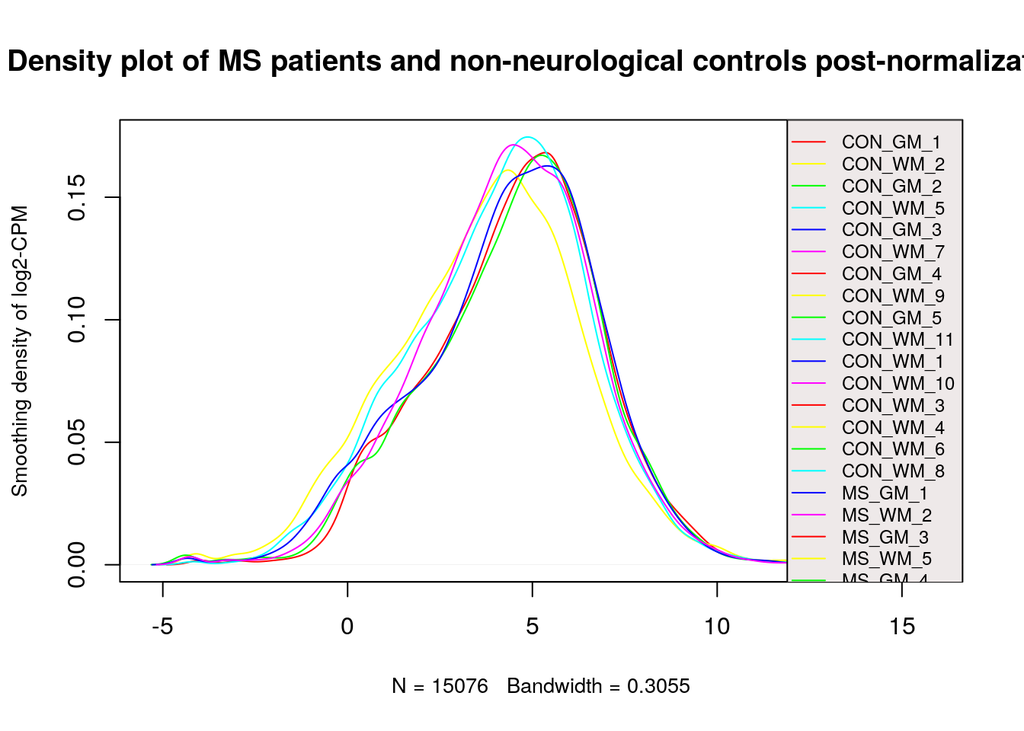

```r
# density plot
densityCounts2 <- apply(log2(edgeR::cpm(expDataNorm[, 3:8])), 2, density)

# calculate limits
xlim <- 0
ylim <- 0
for (i in 1:length(densityCounts2)) {
    xlim <- range(c(xlim, densityCounts2[[i]]$x))
    ylim <- range(c(ylim, densityCounts2[[i]]$y))
}

cols <- rainbow(length(densityCounts2))
ltys <- rep(1, length(densityCounts2))

# plot the first
plot(densityCounts2[[1]], xlim = xlim, ylim = ylim, type = "n", ylab = "Smoothing density of log2-CPM",
    main = "", cex.lab = 0.85)

# plot the lines
for (i in 1:length(densityCounts2)) lines(densityCounts2[[i]], col = cols[i], lty = ltys[i])

# add legend
legend("topright", colnames(data3plot), col = cols, lty = ltys, cex = 0.75, border = "blue",
    text.col = "black", merge = TRUE, bg = "snow2")
title(main = "Density plot of MS patients and non-neurological controls post-normalization")
```

There is not much of a difference between the normalized and the non-normalized data. Additionally, there is the same number of genes between them.

## MDS plot

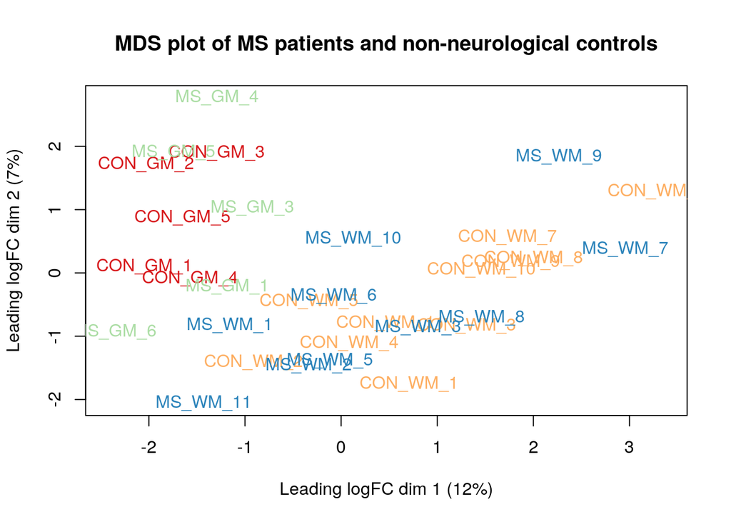

```r
edgeR::plotMDS.DGEList(d, labels=rownames(samples),
  col = colGroup)
title(main="MDS plot of MS patients and non-neurological controls")
```

**Figure 5. MDS plot of all samples, coloured according to `group` which is the combination of `patient_group` and `tissue`.**

The tissues cluster together despite the patient group.

## Dispersion

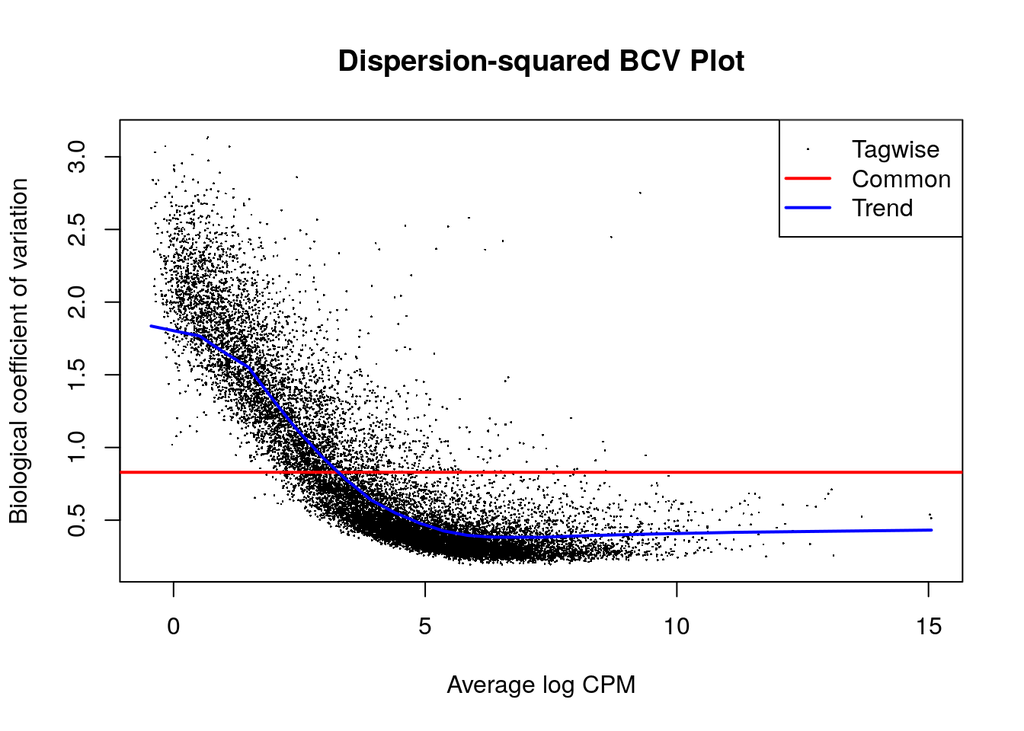

```r
# BCV plot
modelDesign <- model.matrix(~samples$group)
dispersion <- edgeR::estimateDisp(d, modelDesign)
edgeR::plotBCV(dispersion, col.tagwise = "black", col.common = "red", main = "Dispersion-squared BCV Plot")
```

**Figure 6. Dispersion-squared biological coefficient of variation plot of dispersion estimates**

The `plotBCV` function allows us to generate a genewise biological coefficient of variation (BCV) plot of dispersion estimates - showing us the association between the average abundance and the dispersion/BCV. With the red line, we can see the common dispersion estimates the overall BCV averaged over all genes. The black dots represent the tagwise dispersion estimates. The blue curve visualizes the trend of dispersion estimates.

### Final normalized data

```r
kable(head(expDataNorm), format = "html")
```

|  | CON_GM_1 | CON_WM_2 | CON_GM_2 | CON_WM_5 | CON_GM_3 | CON_WM_7 | CON_GM_4 | CON_WM_9 | CON_GM_5 | CON_WM_11 | CON_WM_1 | CON_WM_10 | CON_WM_3 | CON_WM_4 | CON_WM_6 | CON_WM_8 | MS_GM_1 | MS_WM_2 | MS_GM_3 | MS_WM_5 | MS_GM_4 | MS_WM_6 | MS_GM_5 | MS_WM_10 | MS_GM_6 | MS_WM_11 | MS_WM_1 | MS_WM_3 | MS_WM_7 | … |
| --- | --- | --- | --- | --- | --- | --- | --- | --- | --- | --- | --- | --- | --- | --- | --- | --- | --- | --- | --- | --- | --- | --- | --- | --- | --- | --- | --- | --- | --- | --- |
| A1BG | 2.322384 | 0.000000 | 0.000000 | 9.7103050 | 3.869484 | 3.581415 | 4.6494765 | 4.3024563 | 1.6266258 | 6.6811974 | 2.721204 | 5.967154 | 5.044566 | 5.765032 | 4.927762 | 4.138293 | 0.8554522 | 1.7738489 | 3.213864 | 8.109043 | 0.000000 | 0.5555056 | 0.000000 | 12.962222 | 6.125865 | 6.952920 | 3.7862735 | 4.585508 | 12.605552 | … |
| A1BG-AS1 | 0.000000 | 0.000000 | 2.147662 | 2.7131785 | 1.893581 | 3.038778 | 0.8796305 | 2.8840632 | 0.0000000 | 0.7107671 | 0.000000 | 2.893158 | 3.189096 | 6.830349 | 0.000000 | 3.092826 | 2.1101195 | 0.7712382 | 7.026943 | 2.818393 | 0.424570 | 0.0000000 | 1.288421 | 0.000000 | 1.842358 | 4.924984 | 4.1825111 | 6.659921 | 0.000000 | … |
| A2M | 2375.117180 | 2701.025776 | 1721.380356 | 2100.3562559 | 1577.677495 | 1649.732735 | 2074.3340980 | 1617.0633547 | 2213.6882390 | 3197.1069714 | 1326.416102 | 3195.496481 | 3035.030794 | 2534.298386 | 1447.317083 | 2292.614345 | 2769.1598155 | 2908.2613390 | 2767.027859 | 4925.558242 | 1758.502806 | 2804.6216787 | 882.469511 | 482.940011 | 2940.128917 | 4643.169744 | 4741.5600681 | 3959.859310 | 1080.547077 | … |
| A2M-AS1 | 45.339311 | 30.898561 | 5.238205 | 2.2847837 | 7.203817 | 7.759746 | 22.4096463 | 16.6424430 | 13.1116144 | 5.4018379 | 18.198070 | 5.741091 | 11.016874 | 12.908673 | 22.694817 | 6.098517 | 14.7708421 | 2.4679610 | 0.000000 | 5.340111 | 35.631234 | 12.6531833 | 11.149776 | 16.235510 | 36.801178 | 7.387445 | 10.3021788 | 7.205801 | 8.382692 | … |
| A4GALT | 0.000000 | 0.000000 | 0.000000 | 0.8567953 | 1.029117 | 1.899236 | 1.0890661 | 0.9928763 | 0.6407906 | 1.1372296 | 0.000000 | 7.549315 | 1.507570 | 1.691917 | 19.213744 | 6.839044 | 0.0000000 | 4.3189303 | 0.000000 | 0.000000 | 2.090191 | 4.4440436 | 6.541223 | 1.833040 | 0.000000 | 0.000000 | 0.5283173 | 3.220773 | 4.853136 | … |
| AAAS | 39.955610 | 3.212694 | 35.095946 | 28.2741941 | 18.935813 | 30.984699 | 33.4678486 | 41.3224504 | 35.3421322 | 22.8156716 | 16.157172 | 25.360363 | 26.382521 | 13.848604 | 42.496296 | 23.697189 | 22.3558340 | 27.3789378 | 29.578443 | 25.118292 | 41.673185 | 28.3924863 | 24.133136 | 4.582599 | 55.178716 | 24.552482 | 11.2707926 | 26.639626 | 21.051274 | … |

# Task 4: Interpret, and document

### What are the control and test conditions of the dataset?

The control is the **CON** patient group that consisted of non-neurological control donors. This group is compared against the **MS** patient group which consisted of multiple sclerosis patients in two tissues: **GM** (grey matter) and **WM** (white matter) from the brain.

### Why is the dataset of interest to you?

I am currently conducting a research project for the course IMM450 where I am studying the sex bias in antigen-presenting cells in the mouse model experimental autoimmune encephalomyelitis for the human disease multiple sclerosis. While this research project is mainly wet lab, I want to try using bioinformatics to analyze differences in MS.

### Were there expression values that were not unique for specific genes?

There were no duplicated in the gene IDs in the original data set. This stayed the same when trying to conduct identifier mapping.

### How did you handle these?

N/A.

### Were there expression values that could not be mapped to current HUGO symbols?

No.

### How many outliers were removed?

After filtering the lowly expressed genes, we were left with 15076 genes compared to the original 21283. A total of 6207 genes were removed. The number of genes did not change after normalization.

### How did you handle replicates?

All replicates for each patient group and tissue were treated as separate samples. The replicates can be sorted by their `tissue` and their `patient_group`. In the MDS plot, we can see that the samples mostly cluster together as tissues.

### What is the final coverage of your dataset?

The final dataset is made up of:

```
- 15076 with unique identifiers.

- 31 samples in total.

- 2 patient groups *MS* and *CON*, and 2 tissues *GM*, *WM*.

- 10 MS patients and 11 CON

- 10 replicates for WM in the MS group and 11 replicates in the CON group.

- 5 replicates for GM in both patient groups.
```

# References

Davis, Meltzer, S. 2007. “GEOquery: A Bridge Between the Gene Expression Omnibus (GEO) and BioConductor.”

Durinck, Spellman, S. 2009. “Mapping Identifiers for the Integration of Genomic Datasets with the r/Bioconductor Package biomaRt.”

Huber, Carey, W. 2015. “Orchestrating High-Throughput Genomic Analysis with Bioconductor.”

Luo, Jian, C. 2017. “The Role of Microglia in Multiple Sclerosis.” *Neuropsychiatric Disease and Treatment* 13 (1661–1667).

Morgan, Martin. 2022. “BiocManager: Access the Bioconductor Project Package Repository.”

Neuwirth, E. 2022. “RColorBrewer: ColorBrewer Palettes.”

Poel, Ulas van der, M. 2019. “Transcriptional Profiling of Human Microglia Reveals Grey–White Matter Heterogeneity and Multiple Sclerosis-Associated Changes.” *Nat Commun* 10 (1139).

Robinson, McCarthy, M. D. 2010. “edgeR: A Bioconductor Package for Differential Expression Analysis of Digital Gene Expression Data.”

Smyth, G. 2015. “Limma Powers Differential Expression Analyses for RNA-Sequencing and Microarray Studies.”

Zhu, Davis, J. 2008. “GEOmetadb: Powerful Alternative Search Engine for the Gene Expression Omnibus.”